# Reproducible Research: Peer Assessment 1

Rahul

29 July 2017

# Loading and preprocessing the data

```r
#Setting Working Directory
setwd("C:/Users/User/Desktop/Coursera Data/Course 5/Week2")
```

```r
#Reading the data file in R
data_activity <- read.csv("activity.csv")
```

```r
#Checking the dataset
head(data_activity)
```

```
##   steps       date interval
## 1    NA 2012-10-01        0
## 2    NA 2012-10-01        5
## 3    NA 2012-10-01       10
## 4    NA 2012-10-01       15
## 5    NA 2012-10-01       20
## 6    NA 2012-10-01       25
```

```r
dim(data_activity)
```

```
## [1] 17568     3
```

# What is mean total number of steps taken per day?

### Histogram of the total number of steps taken each day

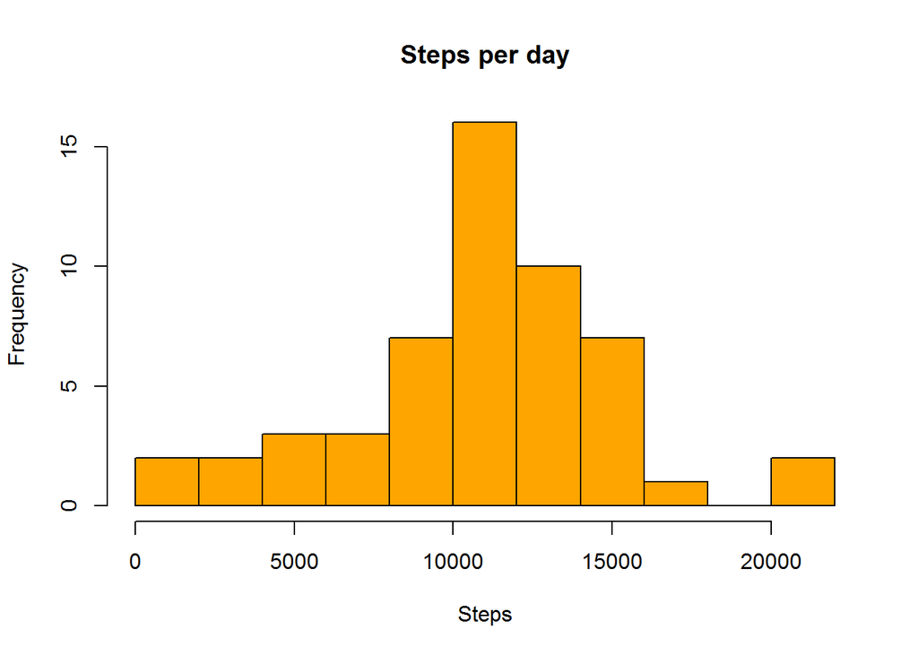

```r
#Finding out total number of steps per day
data_steps_Per_Day <- aggregate(steps ~ date, data_activity, sum,na.rm = TRUE)
hist(data_steps_Per_Day$steps, main = "Steps per day", xlab = "Steps", col = "orange", breaks = 8)
```

```r
meanStepsPerDay <- mean(data_steps_Per_Day$steps)
medianStepsPerDay <- median(data_steps_Per_Day$steps)
```

The median of the steps per day is 10765

# What is the average daily activity pattern?

### Make a time series plot (i.e. type = “l”) of the 5-minute interval (x-axis) and the average number of steps taken, averaged across all days (y-axis)

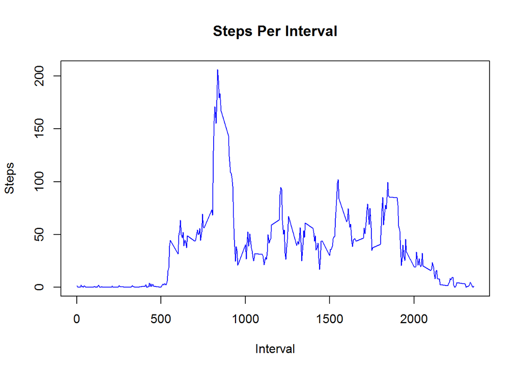

```r
data_steps_Interval <- aggregate(steps ~ interval, data_activity, mean,na.rm = TRUE)
plot(data_steps_Interval$interval, data_steps_Interval$steps, xlab = "Interval", ylab = "Steps", main  = "Steps Per Interval", type = "l", col = "blue")
```

### Which 5-minute interval, on average across all the days in the dataset, contains the maximum number of steps?

```r
max_interval_steps <- data_steps_Interval[which.max(data_steps_Interval$steps),]$interval
```

The interval having the maximunm number of steps is 835

# Imputing missing values

### Calculate and report the total number of missing values in the dataset (i.e. the total number of rows with NAs)

```r
#Finding number of rows with Missing Values
missing_rows <- nrow(data_activity[is.na(data_activity$steps),])
```

The total number of missing values in the dataset is 2304

### Devise a strategy for filling in all of the missing values in the dataset.

The strategy used for filing in all of the missing values with the mean for that day is rejected as there are some days which have all the Steps value as NA e.g, “2012-10-01”. So, the strategy used to fill up the missing values is the with the mean for that 5-minute interval. To achieve this, a function “meanStepsPerInterval” created to get the mean steps for that 5-minute interval.

```r
#Creating function "meanStepsPerInterval" which takes Date as input and returns mean steps for that Date
#It uses the dataset "stepsPerDay" which was created above
meanStepsPerInterval<-function(interval){
    data_steps_Interval[data_steps_Interval$interval == interval,]$steps
}
```

### Create a new dataset that is equal to the original dataset but with the missing data filled in

```r
# Make a new dataset with the original data
data_activity_no_NA<-data_activity
count=0           # Count the number of data filled in
#Replacing the NA values with the mean number of steps for that day
for(i in 1:nrow(data_activity_no_NA)){
    if(is.na(data_activity_no_NA[i,]$steps)){
        data_activity_no_NA[i,]$steps<-meanStepsPerInterval(data_activity_no_NA[i,]$interval)
        count=count+1
    }
}
cat("Total ",count, "NA values were filled.\n\r")
```

```
## Total  2304 NA values were filled.
##
```

### Make a histogram of the total number of steps taken each day and Calculate and report the mean and median total number of steps taken per day

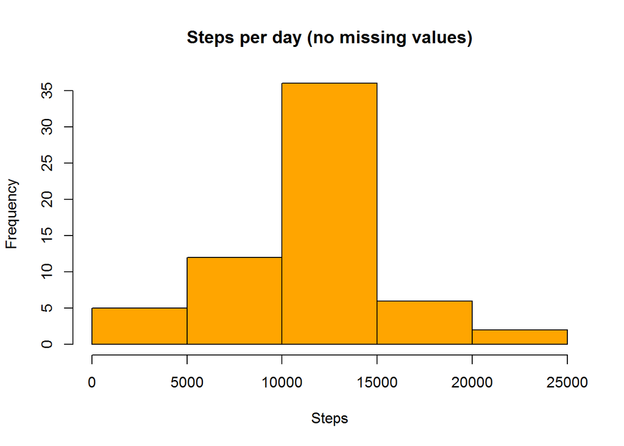

```r
data_Steps_Per_Day_no_NA<-aggregate(steps~date,data=data_activity_no_NA,sum)
hist(data_Steps_Per_Day_no_NA$steps,main = "Steps per day (no missing values)", xlab = "Steps", col = "orange")
```

```r
mean_steps_per_day_no_NA <- mean(data_Steps_Per_Day_no_NA$steps)
median_steps_per_day_no_NA <- median(data_Steps_Per_Day_no_NA$steps)
```

# Are there differences in activity patterns between weekdays and weekends?

### Create a new factor variable in the dataset with two levels - “weekday” and “weekend” indicating whether a given date is a weekday or a weekend day

```r
#Adding field day name to the dataset
data_activity_no_NA$dayname <- weekdays(as.Date(data_activity_no_NA$date))
#Adding field day type to the dataset having levels weekday or weekend
data_activity_no_NA$daytype <- as.factor(ifelse(data_activity_no_NA$dayname %in% c('Saturday', 'Sunday'), "Weekend","Weekday"))
```

### Make a panel plot containing a time series plot (i.e. type = “l”) of the 5-minute interval (x-axis) and the average number of steps taken, averaged across all weekday days or weekend days (y-axis)

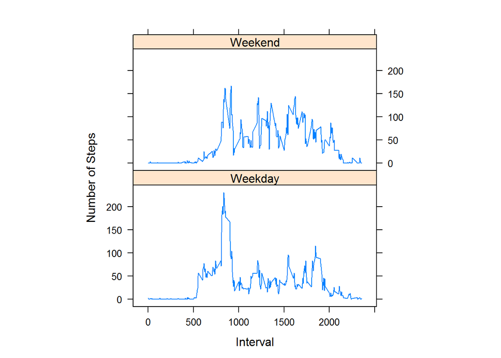

```r
data_activity_no_NA_day_type=aggregate(steps~interval+daytype,data_activity_no_NA,mean)
library(lattice)
xyplot(steps~interval|factor(daytype),data=data_activity_no_NA_day_type,aspect=1/2,type="l",xlab = "Interval", ylab = "Number of Steps")
```